# SPSS_Output_lesson24

Histogram  
Histogram - CESD 19 - I felt that people dislike me - November 19, 2017

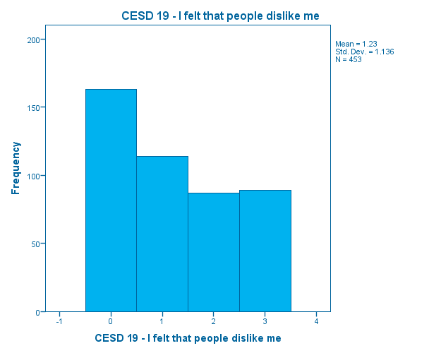

Histogram  
Histogram - CESD 20 - I could not get going - November 19, 2017

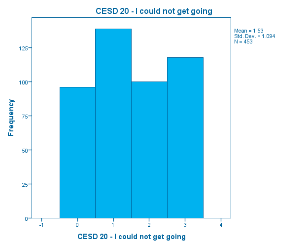

Log  
Log - Log - November 19, 2017

* reverse code items 4,8,12,16  
RECODE f1d f1h f1l f1p (0=3) (1=2) (2=1) (3=0) (SYSMIS=SYSMIS) (ELSE=SYSMIS) INTO f1dr f1hr f1lr  
f1pr.  
EXECUTE.  
* updated labels and codes  
* Define Variable Properties.  
*f1dr.  
VARIABLE LABELS f1dr 'Reverse Coded CESD 4 - I felt that I was just as good as other people'.  
FORMATS f1dr(F8.0).  
VALUE LABELS f1dr  
0 '5-7 days or nearly every day for 2 weeks'  
1 '3-4 days'  
2 '1-2 days'  
3 'not at all or less than 1 day'.  
*f1hr.  
VARIABLE LABELS f1hr 'Reverse Coded CESD 8 - I felt hopeful about the future'.  
FORMATS f1hr(F8.0).  
VALUE LABELS f1hr  
0 '5-7 days or nearly every day for 2 weeks'  
1 '3-4 days'  
2 '1-2 days'  
3 'not at all or less than 1 day'.  
*f1lr.  
VARIABLE LABELS f1lr 'Reverse Coded CESD 12 - I was happy'.  
FORMATS f1lr(F8.0).  
VALUE LABELS f1lr  
0 '5-7 days or nearly every day for 2 weeks'  
1 '3-4 days'  
2 '1-2 days'  
3 'not at all or less than 1 day'.  
*f1pr.  
VARIABLE LABELS f1pr 'Reverse Coded CESD 16 - I enjoyed life'.  
FORMATS f1pr(F8.0).  
VALUE LABELS f1pr  
0 '5-7 days or nearly every day for 2 weeks'  
1 '3-4 days'  
2 '1-2 days'  
3 'not at all or less than 1 day'.  
EXECUTE.  
* check reverse coding.  
FREQUENCIES VARIABLES=f1d f1dr f1h f1hr f1l f1lr f1p f1pr  
/NTILES=4  
/STATISTICS=STDDEV MINIMUM MAXIMUM MEAN  
/HISTOGRAM  
/ORDER=ANALYSIS.

Frequencies  
Frequencies - Statistics - November 19, 2017

StatisticsStatistics, table, 2 levels of column headers and 1 levels of row headers, table with 10 columns and 11 rows

|  | N |  | Mean | Std. Deviation | Minimum | Maximum | Percentiles |  |  |
| --- | --- | --- | --- | --- | --- | --- | --- | --- | --- |
|  | Valid | Missing |  |  |  |  | 25 | 50 | 75 |
| f1d CESD 4 - I felt that I was just as good as other people | 453 | 0 | 1.57 | 1.193 | 0 | 3 | .00 | 1.00 | 3.00 |
| f1dr Reverse Coded CESD 4 - I felt that I was just as good as other people | 453 | 0 | 1.43 | 1.193 | 0 | 3 | .00 | 2.00 | 3.00 |
| f1h CESD 8 - I felt hopeful about the future | 453 | 0 | 1.48 | 1.155 | 0 | 3 | .00 | 1.00 | 3.00 |
| f1hr Reverse Coded CESD 8 - I felt hopeful about the future | 453 | 0 | 1.52 | 1.155 | 0 | 3 | .00 | 2.00 | 3.00 |
| f1l CESD 12 - I was happy | 453 | 0 | 1.08 | 1.010 | 0 | 3 | .00 | 1.00 | 2.00 |
| f1lr Reverse Coded CESD 12 - I was happy | 453 | 0 | 1.92 | 1.010 | 0 | 3 | 1.00 | 2.00 | 3.00 |
| f1p CESD 16 - I enjoyed life | 452 | 1 | 1.34 | 1.137 | 0 | 3 | .00 | 1.00 | 2.00 |
| f1pr Reverse Coded CESD 16 - I enjoyed life | 452 | 1 | 1.66 | 1.137 | 0 | 3 | 1.00 | 2.00 | 3.00 |

Frequency Table  
Frequency Table - f1d CESD 4 - I felt that I was just as good as other people - November 19, 2017

f1d CESD 4 - I felt that I was just as good as other peoplef1d CESD 4 - I felt that I was just as good as other people, table, 1 levels of column headers and 2 levels of row headers, table with 6 columns and 7 rows

|  |  | Frequency | Percent | Valid Percent | Cumulative Percent |
| --- | --- | --- | --- | --- | --- |
| Valid | 0 Not at all or less than 1 day | 116 | 25.6 | 25.6 | 25.6 |
|  | 1 1-2 days | 115 | 25.4 | 25.4 | 51.0 |
|  | 2 3-4 days | 72 | 15.9 | 15.9 | 66.9 |
|  | 3 5-7 days or nearly every day for 2 weeks | 150 | 33.1 | 33.1 | 100.0 |
|  | Total | 453 | 100.0 | 100.0 |  |

Frequency Table  
Frequency Table - f1dr Reverse Coded CESD 4 - I felt that I was just as good as other people - Novem(more)ber 19, 2017(less)

f1dr Reverse Coded CESD 4 - I felt that I was just as good as other peoplef1dr Reverse Coded CESD 4 - I felt that I was just as good as other people, table, 1 levels of column headers and 2 levels of row headers, table with 6 columns and 7 rows

|  |  | Frequency | Percent | Valid Percent | Cumulative Percent |
| --- | --- | --- | --- | --- | --- |
| Valid | 0 5-7 days or nearly every day for 2 weeks | 150 | 33.1 | 33.1 | 33.1 |
|  | 1 3-4 days | 72 | 15.9 | 15.9 | 49.0 |
|  | 2 1-2 days | 115 | 25.4 | 25.4 | 74.4 |
|  | 3 not at all or less than 1 day | 116 | 25.6 | 25.6 | 100.0 |
|  | Total | 453 | 100.0 | 100.0 |  |

Frequency Table  
Frequency Table - f1h CESD 8 - I felt hopeful about the future - November 19, 2017

f1h CESD 8 - I felt hopeful about the futuref1h CESD 8 - I felt hopeful about the future, table, 1 levels of column headers and 2 levels of row headers, table with 6 columns and 7 rows

|  |  | Frequency | Percent | Valid Percent | Cumulative Percent |
| --- | --- | --- | --- | --- | --- |
| Valid | 0 Not at all or less than 1 day | 124 | 27.4 | 27.4 | 27.4 |
|  | 1 1-2 days | 108 | 23.8 | 23.8 | 51.2 |
|  | 2 3-4 days | 100 | 22.1 | 22.1 | 73.3 |
|  | 3 5-7 days or nearly every day for 2 weeks | 121 | 26.7 | 26.7 | 100.0 |
|  | Total | 453 | 100.0 | 100.0 |  |

Frequency Table  
Frequency Table - f1hr Reverse Coded CESD 8 - I felt hopeful about the future - November 19, 2017

f1hr Reverse Coded CESD 8 - I felt hopeful about the futuref1hr Reverse Coded CESD 8 - I felt hopeful about the future, table, 1 levels of column headers and 2 levels of row headers, table with 6 columns and 7 rows

|  |  | Frequency | Percent | Valid Percent | Cumulative Percent |
| --- | --- | --- | --- | --- | --- |
| Valid | 0 5-7 days or nearly every day for 2 weeks | 121 | 26.7 | 26.7 | 26.7 |
|  | 1 3-4 days | 100 | 22.1 | 22.1 | 48.8 |
|  | 2 1-2 days | 108 | 23.8 | 23.8 | 72.6 |
|  | 3 not at all or less than 1 day | 124 | 27.4 | 27.4 | 100.0 |
|  | Total | 453 | 100.0 | 100.0 |  |

Frequency Table  
Frequency Table - f1l CESD 12 - I was happy - November 19, 2017

f1l CESD 12 - I was happyf1l CESD 12 - I was happy, table, 1 levels of column headers and 2 levels of row headers, table with 6 columns and 7 rows

|  |  | Frequency | Percent | Valid Percent | Cumulative Percent |
| --- | --- | --- | --- | --- | --- |
| Valid | 0 Not at all or less than 1 day | 159 | 35.1 | 35.1 | 35.1 |
|  | 1 1-2 days | 151 | 33.3 | 33.3 | 68.4 |
|  | 2 3-4 days | 89 | 19.6 | 19.6 | 88.1 |
|  | 3 5-7 days or nearly every day for 2 weeks | 54 | 11.9 | 11.9 | 100.0 |
|  | Total | 453 | 100.0 | 100.0 |  |

Frequency Table  
Frequency Table - f1lr Reverse Coded CESD 12 - I was happy - November 19, 2017

f1lr Reverse Coded CESD 12 - I was happyf1lr Reverse Coded CESD 12 - I was happy, table, 1 levels of column headers and 2 levels of row headers, table with 6 columns and 7 rows

|  |  | Frequency | Percent | Valid Percent | Cumulative Percent |
| --- | --- | --- | --- | --- | --- |
| Valid | 0 5-7 days or nearly every day for 2 weeks | 54 | 11.9 | 11.9 | 11.9 |
|  | 1 3-4 days | 89 | 19.6 | 19.6 | 31.6 |
|  | 2 1-2 days | 151 | 33.3 | 33.3 | 64.9 |
|  | 3 not at all or less than 1 day | 159 | 35.1 | 35.1 | 100.0 |
|  | Total | 453 | 100.0 | 100.0 |  |

Frequency Table  
Frequency Table - f1p CESD 16 - I enjoyed life - November 19, 2017

f1p CESD 16 - I enjoyed lifef1p CESD 16 - I enjoyed life, table, 1 levels of column headers and 2 levels of row headers, table with 6 columns and 9 rows

|  |  | Frequency | Percent | Valid Percent | Cumulative Percent |
| --- | --- | --- | --- | --- | --- |
| Valid | 0 Not at all or less than 1 day | 137 | 30.2 | 30.3 | 30.3 |
|  | 1 1-2 days | 129 | 28.5 | 28.5 | 58.8 |
|  | 2 3-4 days | 82 | 18.1 | 18.1 | 77.0 |
|  | 3 5-7 days or nearly every day for 2 weeks | 104 | 23.0 | 23.0 | 100.0 |
|  | Total | 452 | 99.8 | 100.0 |  |
| Missing | System | 1 | .2 |  |  |
| Total |  | 453 | 100.0 |  |  |

Frequency Table  
Frequency Table - f1pr Reverse Coded CESD 16 - I enjoyed life - November 19, 2017

f1pr Reverse Coded CESD 16 - I enjoyed lifef1pr Reverse Coded CESD 16 - I enjoyed life, table, 1 levels of column headers and 2 levels of row headers, table with 6 columns and 9 rows

|  |  | Frequency | Percent | Valid Percent | Cumulative Percent |
| --- | --- | --- | --- | --- | --- |
| Valid | 0 5-7 days or nearly every day for 2 weeks | 104 | 23.0 | 23.0 | 23.0 |
|  | 1 3-4 days | 82 | 18.1 | 18.1 | 41.2 |
|  | 2 1-2 days | 129 | 28.5 | 28.5 | 69.7 |
|  | 3 not at all or less than 1 day | 137 | 30.2 | 30.3 | 100.0 |
|  | Total | 452 | 99.8 | 100.0 |  |
| Missing | System | 1 | .2 |  |  |
| Total |  | 453 | 100.0 |  |  |

Histogram  
Histogram - CESD 4 - I felt that I was just as good as other people - November 19, 2017

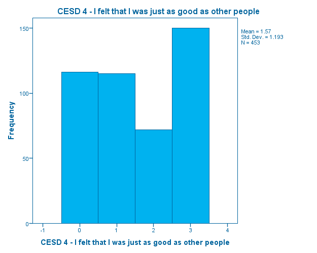

Histogram  
Histogram - Reverse Coded CESD 4 - I felt that I was just as good as other people - November 19, 201(more)7(less)

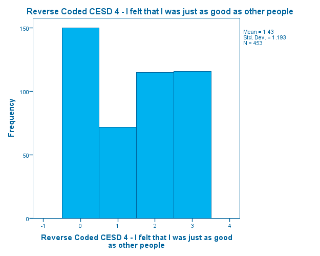

Histogram  
Histogram - CESD 8 - I felt hopeful about the future - November 19, 2017

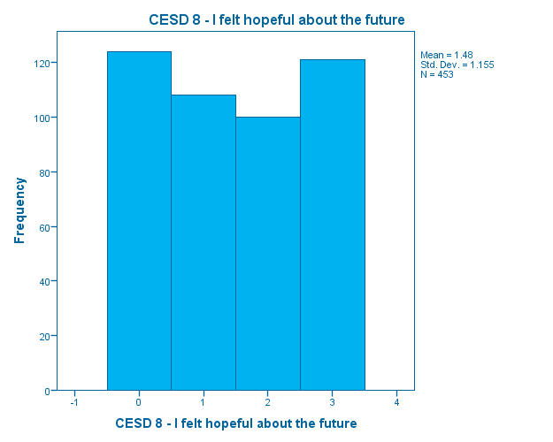

Histogram  
Histogram - Reverse Coded CESD 8 - I felt hopeful about the future - November 19, 2017

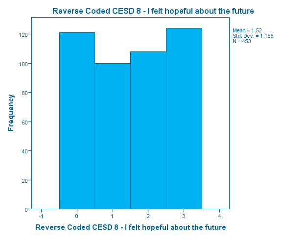

Histogram  
Histogram - CESD 12 - I was happy - November 19, 2017

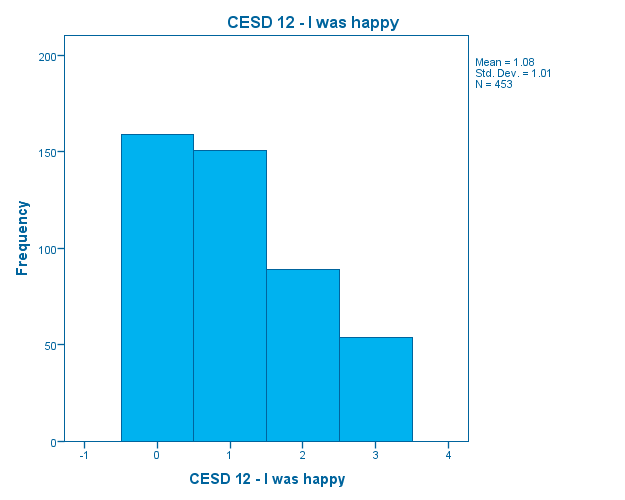

Histogram  
Histogram - Reverse Coded CESD 12 - I was happy - November 19, 2017

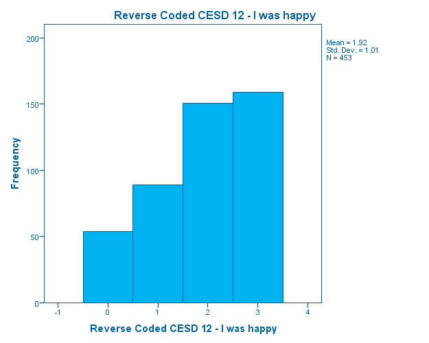

Histogram  
Histogram - CESD 16 - I enjoyed life - November 19, 2017

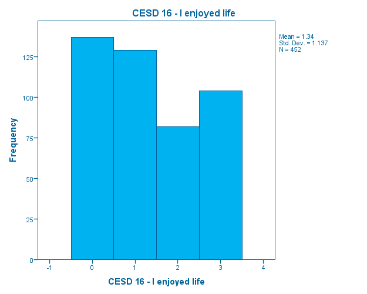

Histogram  
Histogram - Reverse Coded CESD 16 - I enjoyed life - November 19, 2017

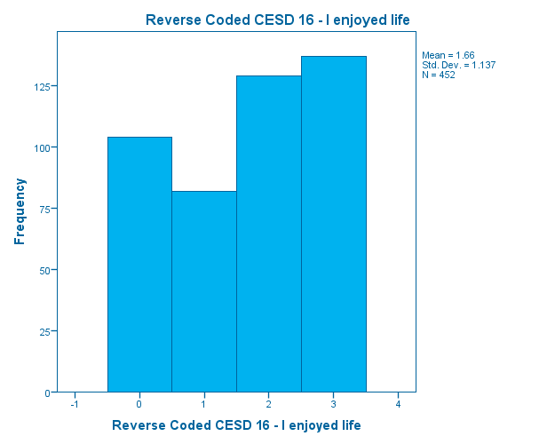

Log  
Log - Log - November 19, 2017

DATASET ACTIVATE DataSet1.  
SAVE OUTFILE='C:\MyGithub\N736Fall2017_lesson24\helpmkh.sav'  
/COMPRESSED.  
* BEFORE computing the total score for the CESD  
* we need to ALWAYS check the assumptions for  
* how the instructions say to handle missing data  
* often these instructions are missing - most instruments/qestionnaires  
* assume COMPLETE answers  
* Missing imputation gets VERY complicated with imputing across  
* multiple items and it's relative impact on the psychometrics of the  
* instrument as designed.  
* However, (based on my readings), in general if <10% of the items are  
* missing or skipped for < 10% of the subjects, you can use  
* mean substitution (across the items WITHIN a subject - NOT BETWEEN subjects)  
* and the impact on bias is minimal.  
* It turns out the CESD allows for up to 20% of the items  
* (which is 4 skipped or missing items) to use mean substitution  
* the % of subjects is not specified - but the lower the better  
* I'd get suspicious if more than 10-20% of the subjects are missing.  
* compute the number of missing items  
* and see how many people have missing items  
COMPUTE nmiss_cesd=nmiss(f1a,f1b,f1c,f1dr,f1e,f1f,f1g,f1hr,f1i,f1j,f1k,f1lr,f1m,f1n,f1o,f1pr,f1q,  
f1r,f1s,f1t).  
EXECUTE.  
FREQUENCIES VARIABLES=nmiss_cesd  
/NTILES=4  
/STATISTICS=STDDEV MINIMUM MAXIMUM MEAN  
/HISTOGRAM  
/ORDER=ANALYSIS.

Frequencies  
Frequencies - Statistics - November 19, 2017

StatisticsStatistics, table, nmiss_cesd, 1 layers, 0 levels of column headers and 2 levels of row headers, table with 3 columns and 11 rows

| nmiss_cesd nmiss_cesd |  |  |
| --- | --- | --- |
| N | Valid | 453 |
|  | Missing | 0 |
| Mean |  | .0155 |
| Std. Deviation |  | .12348 |
| Minimum |  | .00 |
| Maximum |  | 1.00 |
| Percentiles | 25 | .0000 |
|  | 50 | .0000 |
|  | 75 | .0000 |

Frequencies  
Frequencies - nmiss_cesd - November 19, 2017

nmiss_cesdnmiss_cesd, table, 1 levels of column headers and 2 levels of row headers, table with 6 columns and 5 rows

|  |  | Frequency | Percent | Valid Percent | Cumulative Percent |
| --- | --- | --- | --- | --- | --- |
| Valid | .00 | 446 | 98.5 | 98.5 | 98.5 |
|  | 1.00 | 7 | 1.5 | 1.5 | 100.0 |
|  | Total | 453 | 100.0 | 100.0 |  |

Frequencies  
Frequencies - Histogram - November 19, 2017

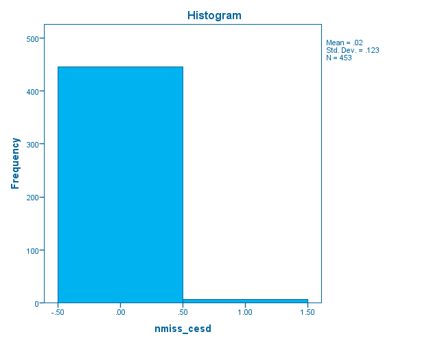

Log  
Log - Log - November 19, 2017

* so 7 subjects/453 = 1.5% of the subjects are missing 1/20 (5%) items  
* so we will use mean substitution to compute the total score  
* to do this we compute the mean and then multiply back by the  
* total number of items. In SPSS and most stats software the mean or sum  
* function treats missing data as removing that item, so if 1 item is missing  
* then the mean is computed out of 19 items instead of 20 items.  
COMPUTE sum_cesd=mean(f1a,f1b,f1c,f1dr,f1e,f1f,f1g,f1hr,f1i,f1j,f1k,f1lr,f1m,f1n,f1o,f1pr,f1q,f1r,  
f1s,f1t) * 20.  
EXECUTE.  
* let's compare what we computed to what is in the HELP dataset.  
FREQUENCIES VARIABLES=cesd sum_cesd  
/NTILES=4  
/STATISTICS=STDDEV MINIMUM MAXIMUM MEAN  
/HISTOGRAM  
/ORDER=ANALYSIS.

Frequencies  
Frequencies - Statistics - November 19, 2017

StatisticsStatistics, table, 2 levels of column headers and 1 levels of row headers, table with 10 columns and 5 rows

|  | N |  | Mean | Std. Deviation | Minimum | Maximum | Percentiles |  |  |
| --- | --- | --- | --- | --- | --- | --- | --- | --- | --- |
|  | Valid | Missing |  |  |  |  | 25 | 50 | 75 |
| cesd CESD total score - Baseline | 453 | 0 | 32.85 | 12.514 | 1 | 60 | 24.50 | 34.00 | 41.00 |
| sum_cesd | 453 | 0 | 32.8717 | 12.51906 | 1.00 | 60.00 | 24.5000 | 34.0000 | 41.0000 |

Frequency Table  
Frequency Table - cesd CESD total score - Baseline - November 19, 2017

cesd CESD total score - Baselinecesd CESD total score - Baseline, table, 1 levels of column headers and 2 levels of row headers, table with 6 columns and 61 rows

|  |  | Frequency | Percent | Valid Percent | Cumulative Percent |
| --- | --- | --- | --- | --- | --- |
| Valid | 1 | 1 | .2 | .2 | .2 |
|  | 3 | 2 | .4 | .4 | .7 |
|  | 4 | 4 | .9 | .9 | 1.5 |
|  | 5 | 1 | .2 | .2 | 1.8 |
|  | 6 | 4 | .9 | .9 | 2.6 |
|  | 7 | 2 | .4 | .4 | 3.1 |
|  | 8 | 3 | .7 | .7 | 3.8 |
|  | 9 | 3 | .7 | .7 | 4.4 |
|  | 10 | 4 | .9 | .9 | 5.3 |
|  | 11 | 5 | 1.1 | 1.1 | 6.4 |
|  | 12 | 4 | .9 | .9 | 7.3 |
|  | 13 | 1 | .2 | .2 | 7.5 |
|  | 14 | 3 | .7 | .7 | 8.2 |
|  | 15 | 9 | 2.0 | 2.0 | 10.2 |
|  | 16 | 7 | 1.5 | 1.5 | 11.7 |
|  | 17 | 8 | 1.8 | 1.8 | 13.5 |
|  | 18 | 7 | 1.5 | 1.5 | 15.0 |
|  | 19 | 8 | 1.8 | 1.8 | 16.8 |
|  | 20 | 4 | .9 | .9 | 17.7 |
|  | 21 | 8 | 1.8 | 1.8 | 19.4 |
|  | 22 | 6 | 1.3 | 1.3 | 20.8 |
|  | 23 | 10 | 2.2 | 2.2 | 23.0 |
|  | 24 | 9 | 2.0 | 2.0 | 24.9 |
|  | 25 | 6 | 1.3 | 1.3 | 26.3 |
|  | 26 | 11 | 2.4 | 2.4 | 28.7 |
|  | 27 | 11 | 2.4 | 2.4 | 31.1 |
|  | 28 | 13 | 2.9 | 2.9 | 34.0 |
|  | 29 | 14 | 3.1 | 3.1 | 37.1 |
|  | 30 | 14 | 3.1 | 3.1 | 40.2 |
|  | 31 | 16 | 3.5 | 3.5 | 43.7 |
|  | 32 | 8 | 1.8 | 1.8 | 45.5 |
|  | 33 | 14 | 3.1 | 3.1 | 48.6 |
|  | 34 | 16 | 3.5 | 3.5 | 52.1 |
|  | 35 | 12 | 2.6 | 2.6 | 54.7 |
|  | 36 | 17 | 3.8 | 3.8 | 58.5 |
|  | 37 | 17 | 3.8 | 3.8 | 62.3 |
|  | 38 | 13 | 2.9 | 2.9 | 65.1 |
|  | 39 | 18 | 4.0 | 4.0 | 69.1 |
|  | 40 | 19 | 4.2 | 4.2 | 73.3 |
|  | 41 | 12 | 2.6 | 2.6 | 75.9 |
|  | 42 | 9 | 2.0 | 2.0 | 77.9 |
|  | 43 | 8 | 1.8 | 1.8 | 79.7 |
|  | 44 | 9 | 2.0 | 2.0 | 81.7 |
|  | 45 | 9 | 2.0 | 2.0 | 83.7 |
|  | 46 | 9 | 2.0 | 2.0 | 85.7 |
|  | 47 | 7 | 1.5 | 1.5 | 87.2 |
|  | 48 | 7 | 1.5 | 1.5 | 88.7 |
|  | 49 | 9 | 2.0 | 2.0 | 90.7 |
|  | 50 | 2 | .4 | .4 | 91.2 |
|  | 51 | 12 | 2.6 | 2.6 | 93.8 |
|  | 52 | 5 | 1.1 | 1.1 | 94.9 |
|  | 53 | 5 | 1.1 | 1.1 | 96.0 |
|  | 54 | 5 | 1.1 | 1.1 | 97.1 |
|  | 55 | 3 | .7 | .7 | 97.8 |
|  | 56 | 3 | .7 | .7 | 98.5 |
|  | 57 | 3 | .7 | .7 | 99.1 |
|  | 58 | 3 | .7 | .7 | 99.8 |
|  | 60 | 1 | .2 | .2 | 100.0 |
|  | Total | 453 | 100.0 | 100.0 |  |

Frequency Table  
Frequency Table - sum_cesd - November 19, 2017

sum_cesdsum_cesd, table, 1 levels of column headers and 2 levels of row headers, table with 6 columns and 66 rows

[output not shown]

Histogram  
Histogram - CESD total score - Baseline - November 19, 2017

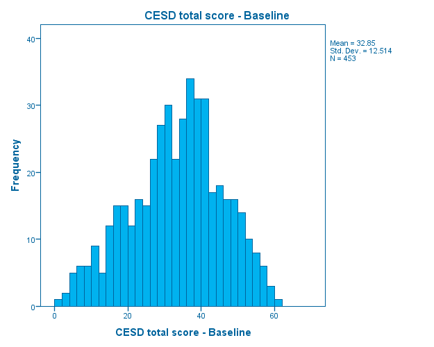

Histogram  
Histogram - sum_cesd - November 19, 2017

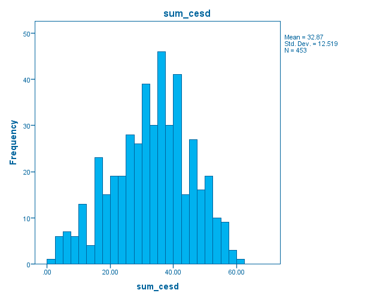